# balamurugan_nagasoundari_ps2

```python
import random
import numpy as np
import scipy
from scipy import stats
from scipy.stats import binom
from scipy.stats import bernoulli
import matplotlib.pyplot as plt
import seaborn as sns
import sklearn.linear_model as lm
import statsmodels.formula.api as smf
```

### 1 How often we get significant results?

```python
num_of_Rep = 1000
num_of_feat = [1, 2, 5]
smple_size = [10, 1000, 10000, 100000]


def callLinearRegression(num_of_feat, smple_size):
    results = [] #Array for storing the results
    for feat in num_of_feat:
        for smple in smple_size:
            x = performLinearRegression(num_of_Rep, feat, smple)
            num_stat_sig = np.mean(np.array(x)>0)
            results.append([smple, feat, num_stat_sig])
    print("[Sample_Size, No_Of_Features, % Significance]")
    for result in results:
        print(result)


def performLinearRegression(iteratn, features, sampSize):
    significant_percent = []
    total_Count = iteratn*(features + 1) #+1 for intercept

    for r in range(1, iteratn+1): #Repeat R times
        ## Create random data and estimate a linear regression model w/statsmodels
        x = np.random.normal(size=(sampSize, features))
        eps = np.random.normal(size=(sampSize, 1))
        y = eps
        X = np.concatenate((np.ones_like(y), x), axis=1)
        model = smf.OLS(y, X)
        fitted_model = model.fit()

        #Statistical significance and p-values
        t_values = fitted_model.tvalues
        p_values = stats.t.sf(np.abs(fitted_model.tvalues), sampSize-features-1)*2
        significant_percent.append(np.mean(np.abs(t_values) > 1.96))

    return significant_percent

new = callLinearRegression(num_of_feat, smple_size)
#print(callLinearRegression(num_of_feat, smple_size))
type(new)
```

```
[Sample_Size, No_Of_Features, % Significance]
[10, 1, 0.14699999999999999]
[1000, 1, 0.096000000000000002]
[10000, 1, 0.112]
[100000, 1, 0.104]
[10, 2, 0.222]
[1000, 2, 0.156]
[10000, 2, 0.153]
[100000, 2, 0.14099999999999999]
[10, 5, 0.39000000000000001]
[1000, 5, 0.251]
[10000, 5, 0.26100000000000001]
[100000, 5, 0.28100000000000003]
```

```
NoneType
```

##### From the results, we could see that the significance increases with number of features added to the linear model. We could also see that for a fixed number of feature, the significance slightly decrease with increase in sample size. Generally, higher sample size, the likelihood of encountering Type-I and Type-II errors occurring reduces. In few cases, the addition of features might reduce the significance as there could be an effect of multicollineraity. But in our model, the significance is higher for more number of features.

### 2. Binomial Distribution

#### 1. Plot the probability mass function and cumulative distribution function of three binomial distributions:

##### a) Binomial(0.3, 1)

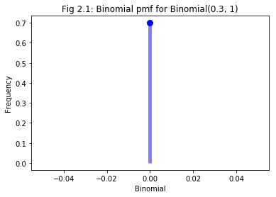

```python
fig, ax = plt.subplots(1, 1)

#Binomial(0.3, 1)
n, p = 1, 0.3
x_range = np.arange(binom.ppf(0.01, n, p), binom.ppf(0.99, n, p))
ax.plot(x_range, binom.pmf(x_range, n, p), 'bo', ms = 8)
ax.vlines(x_range, 0, binom.pmf(x_range, n, p), colors = 'b', lw = 5, alpha = 0.5)
ax.set(xlabel = 'Binomial', ylabel = 'Frequency', title = 'Fig 2.1: Binomial pmf for Binomial(0.3, 1)')
plt.show()
```

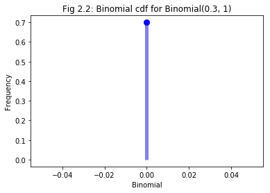

```python
#Binomial(0.3, 1)
fig, ax = plt.subplots(1, 1)
ax.plot(x_range, binom.cdf(x_range, n, p), 'bo', ms = 8)
ax.vlines(x_range, 0, binom.cdf(x_range, n, p), colors = 'b', lw = 5, alpha = 0.5)
ax.set(xlabel = 'Binomial', ylabel = 'Frequency', title = 'Fig 2.2: Binomial cdf for Binomial(0.3, 1)')
plt.show()
```

##### b) Binomial(0.3, 5)

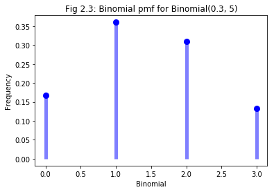

```python
fig, ax = plt.subplots(1, 1)

#Binomial(0.3, 5)
n, p = 5, 0.3
x_range = np.arange(binom.ppf(0.01, n, p), binom.ppf(0.99, n, p))

ax.plot(x_range, binom.pmf(x_range, n, p), 'bo', ms = 8)
ax.vlines(x_range, 0, binom.pmf(x_range, n, p), colors='b', lw=5, alpha=0.5)
ax.set(xlabel = 'Binomial', ylabel = 'Frequency', title = 'Fig 2.3: Binomial pmf for Binomial(0.3, 5)')
plt.show()
```

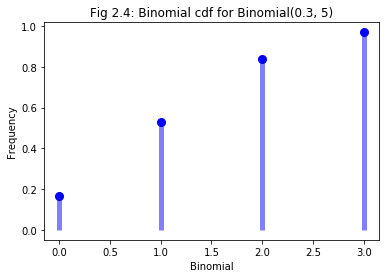

```python
#Binomial(0.3, 5)
fig, ax = plt.subplots(1, 1)
ax.plot(x_range, binom.cdf(x_range, n, p), 'bo', ms = 8)
ax.vlines(x_range, 0, binom.cdf(x_range, n, p), colors = 'b', lw = 5, alpha = 0.5)
ax.set(xlabel = 'Binomial', ylabel = 'Frequency', title = 'Fig 2.4: Binomial cdf for Binomial(0.3, 5)')
plt.show()
```

##### c) Binomial(0.3, 100)

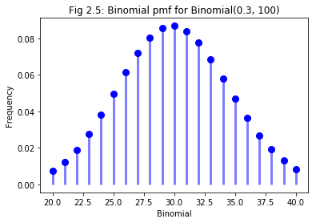

```python
fig, ax = plt.subplots(1, 1)

#Binomial(0.3, 100)
n, p = 100, 0.3
x_range = np.arange(binom.ppf(0.01, n, p), binom.ppf(0.99, n, p))

ax.plot(x_range, binom.pmf(x_range, n, p), 'bo', ms = 8)
ax.vlines(x_range, 0, binom.pmf(x_range, n, p), colors='b', lw=3, alpha=0.5)
ax.set(xlabel = 'Binomial', ylabel = 'Frequency', title = 'Fig 2.5: Binomial pmf for Binomial(0.3, 100)')
plt.show()
```

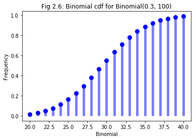

```python
#Binomial(0.3, 100)
fig, ax = plt.subplots(1, 1)
ax.plot(x_range, binom.cdf(x_range, n, p), 'bo', ms = 8)
ax.vlines(x_range, 0, binom.cdf(x_range, n, p), colors = 'b', lw = 5, alpha = 0.5)
ax.set(xlabel = 'Binomial', ylabel = 'Frequency', title = 'Fig 2.6: Binomial cdf for Binomial(0.3, 100)')
plt.show()
```

#### 2. Based on the last case, Binomial(0.3, 100), answer the following question: Assume the probability that a random student on campus speaks Spanish is 0.3. What is the probability that when randomly asking 100 students, we find that less than 25 speak Spanish?

```python
no_of_random_stud = 100
prob = 0.3     # Probability of student speaking spaniah
max_speak = 25

binFunc = binom(no_of_random_stud, prob)

total_prob = 0
for k in range(1, max_speak):
    total_prob += binFunc.pmf(k)

print('The probability of less than 25 students speaking spanish among the 100 randomly selected students is ' + str(total_prob))
```

```
The probability of less than 25 students speaking spanish among the 100 randomly selected students is 0.113570181704
```

##### From Fig 2.6, we could see that, for x < 25(3.75), the frequency is around 0.1. This reconfirms the probability calculation.

#### 3.Create a sample of 100 students - Bernoulli random variables with probability p = 0.3.

#### 4. How many of these speak Spanish (i.e. have value 1)?

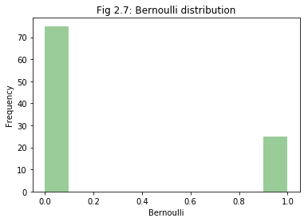

```
The number students that speak spanish in a randomly selected 100 students is 25
```

```python
np.random.seed(100)
# generate bernoulli
data_bern = bernoulli.rvs(size=100, p=0.3)
ax = sns.distplot(data_bern,
                 kde=False,
                 color="green")
ax.set(xlabel='Bernoulli', ylabel='Frequency', title = 'Fig 2.7: Bernoulli distribution')
plt.show()

num_ones = (data_bern == 1).sum()
print('The number students that speak spanish in a randomly selected 100 students is ' + str(num_ones))
```

#### 5. Now repeat these two steps R (1000 is a good choice) times. How often it happens that we find that less than 25 speak Spanish?

```python
np.random.seed(25)
no_of_rep = 1000
spanish_speaking_list = []

def find_spanish_speaking():
    for i in range(num_of_Rep):
        rand_sample = bernoulli.rvs(size=100,p=0.3)
        num_speaking = (rand_sample == 1).sum()
        spanish_speaking_list.append(num_speaking)
    no_of_times_lt_25 = sum(i < 25 for i in spanish_speaking_list)
    return no_of_times_lt_25

spanish_speaking_folks = find_spanish_speaking()
print("No of random samples with less than 25 spanish speaking using bernoulli: " + str(spanish_speaking_folks))
print("Percentage of random samples with less than 25 spanish speaking using bernoulli: " + str(spanish_speaking_folks/10) + "%")
```

```
No of random samples with less than 25 spanish speaking using bernoulli: 105
Percentage of random samples with less than 25 spanish speaking using bernoulli: 10.5%
```

#### 6. Repeat the same simulation using Binomial distribution.

```python
np.random.seed(25)
spanish_speaking_binomial = binom.rvs(n = 100, p = 0.3, size = 1000)
no_of_times_lt_25_binomial = sum(i < 25 for i in spanish_speaking_binomial)

print("No of random samples with less than 25 spanish speaking using binomial distribution: " + str(no_of_times_lt_25_binomial))
print("Percentage of random samples with less than 25 spanish speaking using binomial: " + str(no_of_times_lt_25_binomial/10) + "%")
```

```
No of random samples with less than 25 spanish speaking using binomial distribution: 119
Percentage of random samples with less than 25 spanish speaking using binomial: 11.9%
```

#### By comparing the simulation results from Bernoulli and Binomial distribution, we could see that the number of random samples that has less than 25 spanish speaking students is slightly higher in Binomial distribution(119) than in Bernoulli distribution(105). In bernoulli distribution, the probability is expressed as p and 1-p. But in case of Binomial distribution, there are n independent trials and the probability of getting 1 t times is expressed as (p^t)*((1-p)^(n-t)). This might give us a higher probability. A binomial random variable with parameter n=1 is equivalent to a Bernoulli random variable, i.e. there is only one trial.

### 3. German Tank Problem

```python
num_of_Rep = 1000
actual_max = 71
highest_list = []

np.random.seed(90)
def calculate_probability(n):
    np.random.seed(90)
    highest_list = []
    for i in range(1, num_of_Rep+1):
        rsample = random.sample(range(1,n), 3)
        highest_list.append(max(rsample))

    no_of_max_lt_71 = sum(i <= actual_max for i in highest_list)
    prob_max_lt_71 = no_of_max_lt_71/1000
    return prob_max_lt_71


prob_n_100 = calculate_probability(100)
prob_n_200 = calculate_probability(200)

print("Probability of max values less than 71 when n is 100: " + str(prob_n_100))
print("Probability of max values less than 71 when n is 200: " + str(prob_n_200))
```

```
Probability of max values less than 71 when n is 100: 0.378
Probability of max values less than 71 when n is 200: 0.047
```

```python
n = 100
np.random.seed(90)
while calculate_probability(n) >= .05:
    n = n + 5

print("Value of n so that the probability that the largest captured serial number of 71 is no less than 5%: " + str(n))
```

```
Value of n so that the probability that the largest captured serial number of 71 is no less than 5%: 190
```